# Assignment 2

Hari Subhash Mario

Date created: 2019-05-10

## Abstract

Unpredictable flight delays are a costly problem, forcing travelers to choose between spending unproductive time at the airport and missing a flight. In 2013, flights from the three New York area airports alone saw aggregate delays of half a million minutes.[^1] I explore the predictive capacity with respect to the probability of departure delay of five independent variables – **scheduled departure time**, **atmomspheric pressure**, **visibility**, **the probability associated with each air carrier**, and **the probability associated with each origin airport**. Notably all five of these variables are forecasted ahead of time and made publicly available.

I then use a logistic regression model, and find that all five independent variables display a correlative relationship with departure delay at a 0.1 percent significance level. The data also suggest that scheduled departure time may be used to estimate the probability of departure delay as follows:<sup>2</sup>

> Probability of departure delay = 1 / (1 + e^-(0.27 - 0.0012 * difference between 8pm and scheduled departure time in minutes))

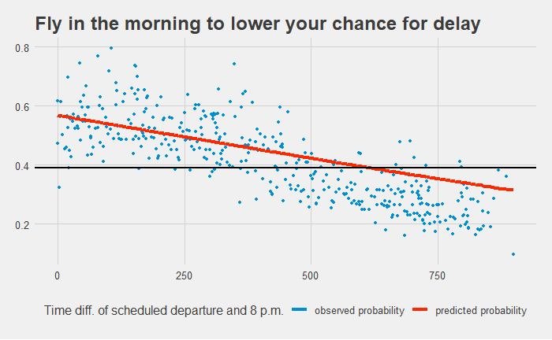

*<sup>1</sup> Bureau of Transportation Statistics, “Reporting Carrier On-Time Performance”, via Rstudio*  
*<sup>2</sup> e refers to Euler’s number, a mathematical constant roughly equal to 2.72*

## Background

### PROBLEM:

Flight delays are unpredictable. Mis-timing your ride to the airport could be costly; Arrive late and you may miss your flight altogether, but arrive early and you’ll spend even more uncomfortable, unproductive time at the gate. In an ideal world, all flights would simply leave on time. In a second-best world, each airline would contact travelers directly with flight delay information that was accurate and timely enough to be actionable. Alas, neither of those are the case.

### GOAL:

My ultimate goal is to be able to best predict whether a flight will be delayed using weather, plane, and flight data.

### HYPOTHESIS:

My null hypothesis is that *no* available weather, plane, or flight data shares a relationship with flight delay. I’ll seek to disprove this.

## Setting up

To set up, I’ll do the following:

1. Set a baseline probability
2. Link flight data with data to the planes flown and the weather contemporaneous to each flight
3. Find a baseline probability for departure delay
4. Clean and adapt the data both so that it makes sense logically and is testable; This will include:
   1. Setting negative departure delay values equal to zero<sup>3</sup>
   2. Replacing categorical data – such as the name of an airline – with an “object effect” that estimates the added chance for delay associated with any object
5. Start an appendix of metadata, including:
   1. A data dictionary
   2. A data lineage diagram

### BASELINE

I’ll set a baseline probability by finding how many flights were delayed in 2013 and dividing by the total number of flights, while accounting for flights that didn’t have delay information available.

### JOIN DATA TABLES

Link tables of flight, plane, and weather data together to create a thick data set

```r
### 3. Join flight, plane, and weather data into a single data frame of raw data to work with
flt_raw <- flights %>%
  left_join(rename(planes,'manuf_year' = year), by = 'tailnum') %>% ## Rename plane manufacture year from 'year' to 'manuf_year' to not confuse it with flight year
  left_join(weather, by = c('time_hour', 'origin'))
```

### REMOVE IRRELEVANT COLUMNS

Some flight, plane, and weather data are relevant or redundant and may be removed

```r
### Remove irrelevant columns
flt_test_00 <- flt_raw %>%
  filter(!is.na(dep_delay) == T) %>%
  select(-year.x, -month.x, -day.x, -hour.x ## Ex ante flight info 1
         ,-minute, -sched_arr_time, -flight ## Ex ante flight info 2
         ,-tailnum, -dest, -time_hour ## Ex ante flight info 3
         ,-dep_time, -arr_time ## Post hoc flight info 1
         ,-arr_delay ,-air_time ## Post hoc flight info 2
         ,-year.y, month.y, -day.y, -hour.y) ## Weather reading time
## Here's what's kept:
##(dep_delay, sched_dep_time, distance, manuf_year, engines ## 1-5
##         ,seats, temp, dewp, humid, wind_speed,wind_gust, precip ## 6-12
  ##       ,pressure, visib, distance ## 13-15
    ##     ,carrier, origin, type, manufacturer ## cat cols 16-19
      ##   ,model, speed ,engine) %>% ## cat cols 20-22
```

### MUTATE SOME COLUMNS

First, convert scheduled departure time to a time object

```r
flt_test_01 <- flt_test_00 %>%
  mutate(sched_dep_time_object = hm(paste
     (trunc(sched_dep_time/100) ## This line provides the hour
         ,str_sub(sched_dep_time,-2,-1)))) ## This line provides the minute
```

Now to look at the delay data based on scheduled departure time

[figure not shown]

Based on the assumption that the delays are approximately symmetric about 8 p.m., I can mutate scheduled departure time by finding the time difference between each scheduled flight time and 8 p.m.

Mutate the other categorical variables. Categorical variables may be used as inputs in a logistic regression. However, I’ll mutate them here into an effect that reflects the difference associated with any given carrier, origin airport, and so forth:

Because travelers may want to refer to delays associated with members of each category, the observed probabilities will be listed in the Appendix alongside their names in a table.

<sup>3</sup> A negative departure delay value would decrease a category mean as though it is “more on time”. To better intuit this, suppose an airline has one flight that leaves 30 minutes early and another that leaves 30 minutes late every day. On paper, the mean of 0 minutes delayed would appear as though a traveler need not worry about delays when flying on this airline, but this is not the case; Rather, there’s a 50 percent chance they’ll depart late. Because of that, I chose to zero out negative departure delay values.

## Univariate analysis

Here are the steps for this

1. Explore metadata to ensure understanding of what each variable represents
2. Descriptive statics of the dependent variable, departure delay, including number of observations, mean, standard deviation, median, min, max, and interquartile measures
3. A histogram will offer a visual representation

Doing this will expose:

- Fields that would be unlikely related to departure delay,
- Fields that will require transformation, and
- Fields with too few observations or with too many missing observations to be representative

### ADDITIONAL METADATA

The package’s documentation offers extensive metadata information.<sup>4</sup>

See appendix for data dictionary and data lineage

### DESCRIPTIVE STATS OF THE DEPENDENT VARIABLE:

To start on building a logistic regression, find a baseline value for the probability that a flight will be delayed, using only the dep_delay column and produce a fairly boring graph

That baseline is 39 percent. This needs to be graphed

```r
as_tibble(op_base) %>%
  ggplot(mapping = aes(x=0, y=0.39094)) +
  geom_point(size = 0) +
  geom_abline(intercept = 0.39094, slope = 0, color = 'blue', size = 1) +
  scale_color_fivethirtyeight() +
  theme_fivethirtyeight() +
  ggtitle('Assume a 39 percent chance of delay if no data') +
  theme(axis.title.x=element_blank(),
        axis.text.x=element_blank(),
        axis.ticks.x=element_blank())
```

[output not shown]

*<sup>4</sup> See [nycflights documentation](https://cran.r-project.org/web/packages/nycflights13/nycflights13.pdf)*

## Multivariate analysis

There are steps here too

1. Descriptive statistics for the independent variables
2. Explore relationships between variables
3. Find correlation with our dependent variable
4. Model the best relationships

### Descriptive statistics for the independent variables

Based on the data dictionary, the following fields are either unlikely to be related to departure delay or duplicative of another, superior field in the data set

- Destination
- Tail number
- Arrival time
- Day of the month
- Flight number
- Scheduled arrival time
- Year
- Air time
- Arrival delay
- Departure time
- Distance

Only one field among those remaining, **wind gust**, is concerning due to the number of n/a entries – 256,391 of 336,776 total. My fear is that these incomplete entries are biased – that is, we may be telling a story that is based on a sample of the data that does not represent the poopulation.

To test, I’ll produce summary statistics for wind gusts that are present and missing:

```r
flt_test_03 %>%
  select(wind_gust,is_delay) %>%
  filter(is.na(is_delay) == F) %>%
  mutate(na_gust = factor(if_else(is.na(wind_gust), 0, 1)
                             ,levels = c(0,1)
                             ,labels = c('null', 'not null') )) %>%
  ggplot(aes(is_delay, fill = 'density whether wind gust is NA')) +
  geom_density() +
  ggtitle(label = 'Delay chance differs when wind gust is na but thats OK') +
  theme_fivethirtyeight() +
  facet_wrap(~na_gust, nrow = 2, ncol = 1)
```

[output not shown]

These look similar enough to work with. To further verify with numbers, I would do a z-test to see if I’m able to disprove that the means are unequal and an f-test to do the same with the standard deviations. But not today. Today, I will do neither.

### Explore relationships

In testing departure delay and our other variables, I’ll be looking for relationships that show a strong, correlative relationship.

To do this, I’ll use R’s general linear model (glm) tool. This will expose the strength of each relationship by providing a p-value, which estimates the probability that we’d get at least as extreme a result if NYC flights 2013 were repeated forever. Because we want there to be *little* chance that sampling the actual population gives us results that are extreme relative to our model, we want p-values that are as low as possible.

**I will test the dataset I’ve created with a significance level of 0.1 percent.**

```r
glm_test <- glm(data = flt_test_03, is_delay ~ distance + manuf_year + engines + seats + speed + month.y + temp + dewp + humid + wind_dir + wind_speed + wind_gust + precip + pressure + visib + diff_20h + op_carr + op_ogn + op_type + op_mnf + op_mdl + op_spd + op_eng, family = binomial)

summary(glm_test)

glm_test <- glm(data = flt_test_03, is_delay ~ month.y + temp + humid + wind_gust + diff_20h + op_carr + op_mdl, family = binomial)

summary(glm_test)
```

[output not shown]

### Find correlation with our dependent variable

```r
flt_test %>%
  select(diff_20h, humid, pressure, visib, op_carr, op_ogn, op_mnf, op_mdl, op_eng) %>%
  cor(use = 'pairwise.complete.obs') %>%
  round(2) %>%
  as_tibble() %>%
  mutate(field = c('diff_20h', 'humid', 'pressure', 'visib', 'op_carr', 'op_ogn', 'op_mnf', 'op_mdl', 'op_eng'))
```

[output not shown]

```r
tibble(humid = c(.54, NaN, NaN, NaN, NaN)
       ,op_carr = c(NaN, 0.45, 0.52, 0.79, 0.37)
       ,op_ogn = c(NaN, NaN, .36, .48, NaN)
       ,op_mnf = c(NaN, NaN, NaN, .58, .59)
       ,op_mdl = c(NaN, NaN, NaN, NaN, .35)
       ,field = c("visib", "op_ogn", "op_mnf", "op_mdl", "op_eng"))
```

Humidity is highly correlated with visibility. This makes sense since water vapor in the air makes it more difficult to see. -humid

Carrier is highly correlated with four variables which are also correlated with each other – airport of origin, manufacturer, model, and engine. This makes sense because having more of its planes concentrated at one airport provides economies of scale and manufacturers – who sell plane models with engines in them – are likely to cut a deal with those who buy in bulk. -op_mnf, -op_mdl, -op_eng

This brings us to our final five variables: diff_20h, pressure, visib, op_carr, op_ogn

```r
flt_final <- flt_test_03 %>%
  select(dep_delay, diff_20h, pressure, visib, op_carr, op_ogn)
```

### Model the best relationships

To figure out which single variable is most closely associated with probability of flight delay, I’ll build another logistic regression model

```r
glm_test <- glm(data = flt_final, dep_delay ~ diff_20h + pressure + visib + op_carr + op_ogn, family = binomial)

summary(glm_test)

for(i in 1:6) print(as.numeric(coefficients(glm_test)[i]))
```

[output not shown]

Here is the equation that estimates the probability of your flight being delayed using five inputs:

1/(1+e^-( 24.54178 - 0.00116677 x diff_20h - 0.02320652 x pressure - 0.07679695 x visib + 4.169445 x op_carr + 1.73226 x op_ogn ))

To get a result with only one input, I can repeat the same:

```r
glm_test <- glm(data = flt_final, dep_delay ~ diff_20h, family = binomial)

summary(glm_test)

for(i in 1:2) print(as.numeric(coefficients(glm_test)[i]))
```

[output not shown]

Here is the equation that estimates the probability of a flight being delayed using one input:

1/(1+e^-(0.2746527 - 0.001169423 x diff_20h))

Now that I’ve got this equation, I’ll plot the observed probability for each group of scheduled departure times on the same graph as my predicted probability. I also include the baseline probability to show how much this estimate has improved.

```r
### I'm starting with raw data to build this completed graph, so that it still works if I skip ahead. Also, so I can practice

test_a <- flights %>% ###
  select(sched_dep_time, dep_delay) %>%
  filter(!is.na(dep_delay) == T) %>%
  filter(sched_dep_time %in% (flights %>% ### Is the time one of those with too few entries?
             group_by(sched_dep_time) %>% ### Here, I'm grouping by departure time
             summarise(n = length(sched_dep_time)) %>%
             filter(n >= 100) %>% ### And here, I'm filtering out any group that has fewer than 100 entries. Because airlines generally schedule flights on each route on different days at the same times, there should be plenty of groups remaining
             select(sched_dep_time) %>%
             unique() %>% ### Not necessary
             unlist() %>% ### Selecting one column gives me a list so this changes it back to vector
             as.character() %>%
             as.integer())) %>% ### The end of the subquery
  mutate(is_delay = if_else(dep_delay > 0, 1, 0) ### Here's where I convert from a dep_delay in minutes to a binary is_delay
           ,diff_20h = if_else(sched_dep_time < 2000
                            ,1960 - sched_dep_time
                            ,sched_dep_time - 2000)) %>%
  group_by(diff_20h) %>%
  mutate(op_diff20 = sum(is_delay) / length(is_delay)) %>%
  ungroup() %>%
  as_tibble()

test_b <- cbind(test_a, tibble(sched_dep_time_diff_8pm = sample(0:1460, nrow(test_a),replace=T))) %>% ### Here, I'm just giving myself a column with random numbers within the relevant range to be used for the x-axis
  mutate(prob_delay = 1/(1+exp(-(0.2746527 - 0.001169423 * sched_dep_time_diff_8pm))))



test_b %>%
  ggplot(aes(sched_dep_time_diff_8pm, prob_delay)) +
  geom_line(size = 1.5, color = 'orange') +  ### This is predicted probability by scheduled departure time
  ggtitle('Fly in the morning to lower your chance for delay') +
  scale_color_fivethirtyeight() +
  theme_fivethirtyeight() +
  geom_point(data = test_b, aes(x = diff_20h, y = op_diff20), color = 'gray') + ### These are all the observed probabilities by scheduled departure time
  geom_hline(yintercept = 0.39094, color='blue', size = 1) ### This is the baseline probability
```

## Ax.1 Metadata

**DATA LINEAGE**

The following may serve as a data lineage diagram

| Original_source | nycflights13 | raw_data_joined | adapted_data |
| --- | --- | --- | --- |
| transtats.bts.gov/DL_SelectFields.asp?Table_ID=236 | airlines | n/a | n/a |
| RITA, Bureau of transportation statistics,transtats.bts.gov/DL_SelectFields.asp?Table_ID=236 | flights | flt_raw | flt_test |
| FAA Aircraft registry,faa.gov/licenses_certificates/aircraft_certification/aircraft_registry/releasable_aircraft_download/ | planes | flt_raw | flt_test |
| ASOS download from Iowa Environmental Mesonet, mesonet.agron.iastate.edu/request/download.phtml | weather | flt_raw | flt_test |

**DATA DICTIONARY**

The following table links assets as saved in nycflights13 with associated terms and definitions.

| table | field | term | definition |
| --- | --- | --- | --- |
| flights | year | year,month,day | Date of departure or date of weather recording |
| flights | month | year,month,day | Date of departure or date of weather recording |
| flights | day | year,month,day | Date of departure or date of weather recording |
| flights | dep_time | dep_time,arr_time | Actual departure and arrival times (format HHMM or HMM), local tz. |
| flights | sched_dep_time | sched_dep_time,sched_arr_time | Scheduled departure and arrival times (format HHMM or HMM), local tz. |
| flights | dep_delay | dep_delay,arr_delay | Departure and arrival delays, in minutes. Negative times represent early departures/arrivals. |
| flights | arr_time | dep_time,arr_time | Actual departure and arrival times (format HHMM or HMM), local tz. |
| flights | sched_arr_time | sched_dep_time,sched_arr_time | Scheduled departure and arrival times (format HHMM or HMM), local tz. |
| flights | arr_delay | dep_delay,arr_delay | Departure and arrival delays, in minutes. Negative times represent early departures/arrivals. |
| flights | carrier | carrier | Two letter carrier abbreviation. See airlines() to get name |
| flights | flight | flight | Flight number |
| flights | tailnum | tailnum | Plane tail number |
| flights | origin | origin | Origin of flight or weather station |
| flights | dest | dest | Destination of flight. See airports() for additional metadata. |
| flights | air_time | air_time | Amount of time spent in the air, in minutes |
| flights | distance | distance | Distance between airports, in miles |
| flights | hour | hour | Hour part of time of scheduled departure or weather recording |
| flights | minute | minute | Minute part of time of scheduled departure |
| flights | time_hour | time_hour | Scheduled date and hour of the flight or of the weather recording as a POSIXct date |
| weather | origin | origin | Origin of flight or weather station |
| weather | year | year,month,day | Date of departure or date of weather recording |
| weather | month | year,month,day | Date of departure or date of weather recording |
| weather | day | year,month,day | Date of departure or date of weather recording |
| weather | hour | hour | Hour part of time of scheduled departure or weather recording |
| weather | temp | temp,dewp | Temperature and dewpoint in F |
| weather | dewp | temp,dewp | Temperature and dewpoint in F |
| weather | humid | humid | Relative humidity |
| weather | wind_dir | wind_dir,wind_speed,wind_gust | Wind direction (in degrees), speed and gust speed (in mph) |
| weather | wind_speed | wind_dir,wind_speed,wind_gust | Wind direction (in degrees), speed and gust speed (in mph) |
| weather | wind_gust | wind_dir,wind_speed,wind_gust | Wind direction (in degrees), speed and gust speed (in mph) |
| weather | precip | precip | Precipitation, in inches |
| weather | pressure | pressure | Sea level pressure in millibars |
| weather | visib | visib | Visibility in miles |
| weather | time_hour | time_hour | Scheduled date and hour of the flight or of the weather recording as a POSIXct date |
| planes | tailnum | tailnum | Plane tail number |
| planes | year | year(2) | Year manufactured,Renamed to manuf_year |
| planes | type | type | Type of plane |
| planes | manufacturer | manufacturer,model | Manufacturer and model |
| planes | model | manufacturer,model | Manufacturer and model |
| planes | engines | engines,seats | Number of engines and seats |
| planes | seats | engines,seats | Number of engines and seats |
| planes | speed | speed | Average cruising speed in mph |
| planes | engine | engine | Type of engine |

This table represents a table of static data linking airline codes to airline descriptions:

| carrier_code | carrier_description |
| --- | --- |
| 9E | Endeavor Air Inc. |
| AA | American Airlines Inc. |
| AS | Alaska Airlines Inc. |
| B6 | JetBlue Airways |
| DL | Delta Air Lines Inc. |
| EV | ExpressJet Airlines Inc. |
| F9 | Frontier Airlines Inc. |
| FL | AirTran Airways Corporation |
| HA | Hawaiian Airlines Inc. |
| MQ | Envoy Air |
| OO | SkyWest Airlines Inc. |
| UA | United Air Lines Inc. |
| US | US Airways Inc. |
| VX | Virgin America |
| WN | Southwest Airlines Co. |
| YV | Mesa Airlines Inc. |

For categorical independent variables, the below table, cat_facts, shows associated departure delay. If desired, it could also be used for manual back-transformation

```r
cat_facts %>% mutate(facts = round(facts,4))
```

[output not shown]

## Ax.2 For further study

### On working with a binary delay rather than a time of delay

Here’s the histogram for dep_delay again

```r
flights %>%
  ggplot(mapping = aes(dep_delay)) +
  geom_histogram(na.rm = T) +
  theme_fivethirtyeight() +
  scale_color_fivethirtyeight() +
  labs(title = 'A large majority of flights clump around 0'
         ,subtitle = paste('But', sum(flights$dep_delay >= 600, na.rm = T), 'flights delayed more than 10 hours skew everything'))
```

[output not shown]

Regardless of which category I grouped flights by, it was apparent that most flights in 2013 saw little to no delay. However, because there were a handful of outliers, it could skew the data when using mean, dramatically altering my results for a categorical variable. In turn, my predictions based on mean would be pretty far off most of the time, and only useful when averaging out a large number of flights that any given traveler might not make in a lifetime.

As an example, suppose a carrier was on time 99 times, but once, due to a fluke occurence of icy rain, was delayed by 15 hours.

```r
tibble(dep_delay = c(rep(0.0,99), 15*60)) %>%
  ggplot(mapping = aes(dep_delay)) +
  geom_density(na.rm=T) +
  geom_vline(xintercept = 9, color = 'darkred', size = 2) +
  theme_fivethirtyeight() +
  scale_color_fivethirtyeight() +
  xlim(-1, 30) +
  labs(caption = 'I set x-axis max limit to 30 min., so the bar at 900 isnt visible'
       ,title = 'The mean delay in red tells us nothing very useful')
```

[output not shown]

### Picking a cutoff

One concern I had with this approach was ignoring much of the data. In particular, ignoring the magnitude of delay mattered because cutting off delayed vs. not delayed at 0 minutes was somewhat arbitrary.

There’s a differnce between being delayed five minutes and being delayed an hour – few would even notice the former while the latter would require a phone call or two to change plans.

```r
flights %>% filter(!is.na(dep_delay) == T, dep_delay > 15) %>% ggplot(mapping = aes(dep_delay)) + geom_histogram(binwidth = 10) + theme_fivethirtyeight() +
  scale_color_fivethirtyeight()

flights %>% filter(!is.na(dep_delay) == T, dep_delay > 30) %>% ggplot(mapping = aes(dep_delay)) + geom_histogram(binwidth = 10) + theme_fivethirtyeight() +
  scale_color_fivethirtyeight()

flights %>% filter(!is.na(dep_delay) == T, dep_delay > 60) %>% ggplot(mapping = aes(dep_delay)) + geom_histogram(binwidth = 10) + theme_fivethirtyeight() +
  scale_color_fivethirtyeight()
```

[output not shown]

For each of these, we always run into the same problem which is that the data remains clumped toward the left side and is highly skewed rightward. So picking 0 is as good as any.

### Adding a second-level test for expected minutes delayed given that a flight is delayed

See the previous section. The heavy skew of the data means that number is likely to be off by a good amount.

### Test formula using a succeeding year’s data

There are updates to the flight data for as recently as 2017. Let’s see how the formula did at predicting. You may need to download this file and store it in the directory you have this notebook: http://mariobonifacio.github.io/flights17.rds

```r
### I can't get this download to work because of some github security probably, so just get it from here: http://mariobonifacio.github.io/flights17.rds
# Then put that file in this directory
library(RCurl)
#
f <- CFILE("flights17.rds", mode="wb")
curlPerform(url = "http://mariobonifacio.github.io/flights17.rds", writedata = f@ref, noprogress=FALSE) # If this line doesn't work, download and put in the directory of this notebook
close(f)
flights_17 <- read_rds("flights17.rds")

flights_17 %>%
  filter(!is.na(dep_delay) == T) %>%
  mutate(diff_20h = if_else(sched_dep_time < 2000
                                ,1960 - sched_dep_time
                                ,sched_dep_time - 2000)) %>%
  group_by(diff_20h) %>%
  summarise(op_delay = sum(dep_delay > 0) / length(dep_delay)) %>%
  mutate(pred_prob = 1/(1+exp(-(0.2746527 - 0.001169423 * diff_20h)))) %>%
  ggplot(mapping = aes(x = diff_20h, y = pred_prob)) +
  geom_line(color = 'orange', size = 2) +
    geom_point(mapping = aes(x = diff_20h, y = op_delay), color = 'gray') +
  theme_fivethirtyeight() +
  scale_color_fivethirtyeight() +
  ggtitle('My bivariate logistic regression model works well on 2017 data')
```

[output not shown]